# ggplot - Datacamp

# Smoothing

Welcome to the exercises for the second ggplot2 course!

To practice on the remaining four layers (statistics, coordinates, facets and themes), we’ll continue working on several datasets that we already encountered in the first course.

The mtcars dataset contains information for 32 cars from Motor Trends magazine from 1973. This dataset is small, intuitive, and contains a variety of continuous and categorical (both nominal and ordinal) variables.

In the previous course we learned how to effectively use some basic geometries, such as point, bar and line. In the first chapter of this course we’ll explore statistics associated with specific geoms, for example, smoothing and lines.

Familiarize yourself again with the mtcars dataset using str().

```r
str(mtcars)
```

[output not shown]

Extend the first ggplot call: add a LOESS smooth to the scatter plot (which is the default) with geom_smooth(). We want to have the actual values and the smooth on the same plot.

```r
library(ggplot2)
ggplot(mtcars, aes(x = wt, y = mpg)) +
  geom_point() +
  geom_smooth()
```

[output not shown]

Change the previous plot to use an ordinary linear model, by default it will be y ~ x, so you don’t have to specify a formula. You should set the method argument to “lm”.

```r
library(ggplot2)
ggplot(mtcars, aes(x = wt, y = mpg)) +
  geom_point() +
  geom_smooth(method = "lm")
```

[output not shown]

We’ll continue with the previous exercise by considering the situation of looking at sub-groups in our dataset. For this we’ll encounter the invisible group aesthetic.

In this ggplot command our smooth is calculated for each subgroup because there is an invisible aesthetic, group which inherits from col.

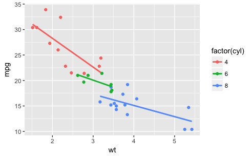

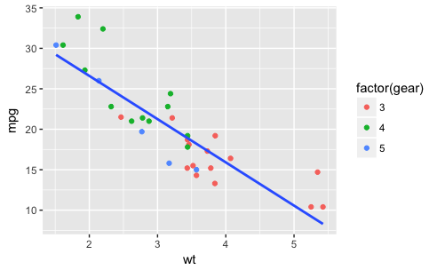

Plot 1: Recall that LOESS smoothing is a non-parametric form of regression that uses a weighted, sliding-window, average to calculate a line of best fit. We can control the size of this window with the span argument.

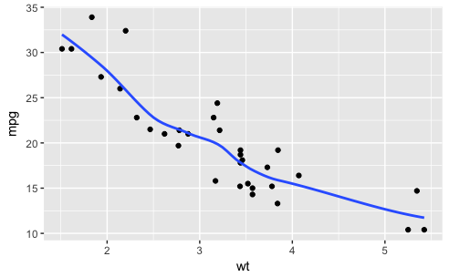

Plot 1: Recall that LOESS smoothing is a non-parametric form of regression that uses a weighted, sliding-window, average to calculate a line of best fit. We can control the size of this window with the span argument.

Add span, set it to 0.7.

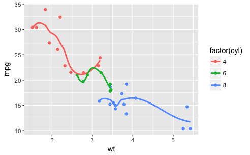

Set method to “loess” (this is the default with a small (n < 1000) data set, but we will specify it explicitly). Add span, set it to 0.7.

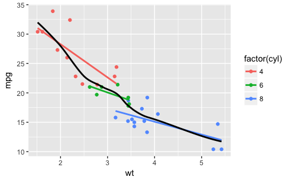

Plot 3: Plot 2 presents a problem because there is a black line on our plot that is not included in the legend. To get this, we need to map something to col as an aesthetic, not just set col as an attribute.

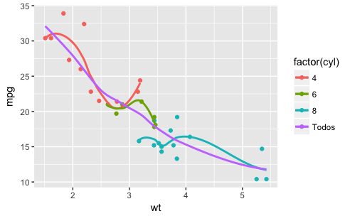

Manual scale

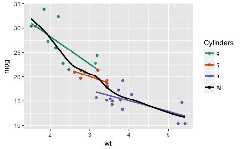

## Modifying stat_smooth (2)

In this exercise we’ll take a look at a more subtle example of defining and using linear models. ggplot2 and the Vocab data frame are already loaded for you.

Plot 1: This code produces a jittered plot of vocabulary against education, variables from the Vocab data frame.

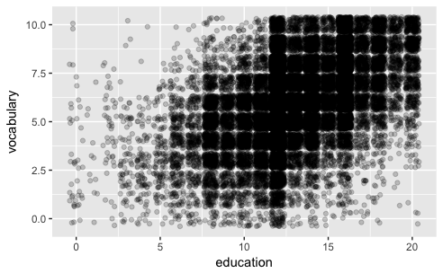

Add a stat_smooth() layer with method set to “lm”. Hide the CI ribbons by using se = FALSE

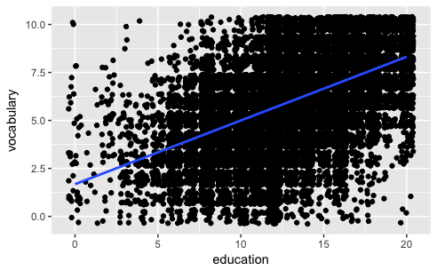

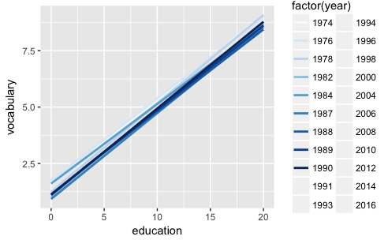

Plot 5: To get the proper colors, we can use col = year, because the variable year is type integer and we want a continuous scale. However, we’ll need to specify the invisible group aesthetic so that our linear models are still calculated appropriately. The scale layer, scale_color_gradientn(), has been provided for you - this allows us to map a continuous variable onto a colour scale.

Add group = factor(year) inside aes(). Inside stat_smooth(), set alpha = 0.6 and size = 2.

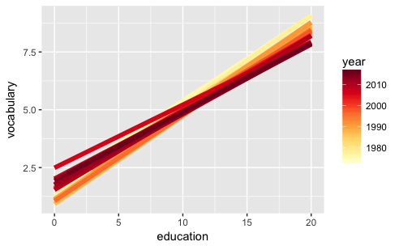